# Chapter 08 Exercises

## Spencer Hodapp

### 1/25/2020

```python
# Libraries you will need for this assignment.
# The code below will import them for your use.
# Please run this before continuing.
%matplotlib inline
import numpy as np
import pandas as pd
import matplotlib.pyplot as plt
```

## Q1) Inflation in China and India (FRED Question)

Using the data found [Here](https://github.com/dylanjm/econ_381_development/tree/master/data) import the inflation rates for `ch08_china_inflation.csv` and `ch08_india_inflation.csv`. Ensure to use the **raw url** for your Python code. Use your chapter 7 homework as a guide. I have already imported the data for china and converted it to arrays, so you will need to do the same for India and plot everything.

**(a)**: Using Python, create two time series plots showing the inflation rate for China and India for the years given in the data.

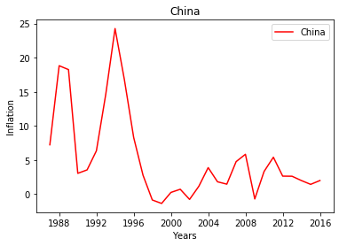

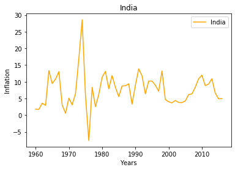

```python
# Import the data sets
china_url = "https://raw.githubusercontent.com/dylanjm/econ_381_development/master/data/ch08_china_inflation.csv"
china = pd.read_csv(china_url,header=0, names=['Date', 'China'])

india_url = "https://raw.githubusercontent.com/dylanjm/econ_381_development/master/data/ch08_india_inflation.csv"
india = pd.read_csv(india_url,header=0, names=['Date', 'India'])

#Convert the date variable to a datetime object
ChinaDate = np.array(china['Date'], dtype = np.datetime64)
ChinaInflation = np.array(china['China'])

IndiaDate = np.array(india['Date'], dtype = np.datetime64)
IndiaInflation = np.array(india['India'])

plt.plot(ChinaDate, ChinaInflation, label= "China", c= "red")
plt.title('China')
plt.xlabel('Years')
plt.ylabel('Inflation')
plt.legend()
plt.show()

plt.plot(IndiaDate, IndiaInflation, label= "India", c= "orange")
plt.title('India')
plt.xlabel('Years')
plt.ylabel('Inflation')
plt.legend()
plt.show()
#plot
```

**(b)**: What is the average inflation rate in each country for the most recent 5 years of data? What country had lower inflation?

```python
# Python Code for Part (b) Here:

#India

print("India Average Inflation")

iyear2=(IndiaInflation[-4]/100+1)*100
iyear3=iyear2 * (IndiaInflation[-3]/100+1)
iyear4=iyear3 * (IndiaInflation[-2]/100+1)
iyear5=iyear4 * (IndiaInflation[-1]/100+1)

india_cpiavg = (iyear5 / 100)**(1/5) - 1
print ('{:,.2%}'.format(india_cpiavg))

#China

print("China Average Inflation")

cyear2=(ChinaInflation[-4]/100+1)*100
cyear3=cyear2 * (ChinaInflation[-3]/100+1)
cyear4=cyear3 * (ChinaInflation[-2]/100+1)
cyear5=cyear4 * (ChinaInflation[-1]/100+1)

china_cpiavg = (cyear5 / 100)**(1/5) - 1
print ('{:,.2%}'.format(china_cpiavg))
```

```
India Average Inflation
5.42%
China Average Inflation
1.61%
```

## Q2) Inflation and the quantity theory

Suppose velocity is contant, the growth rate of real GDP is 3% per year, and the growth rate of money is 5% per year. Calculate the long-run rate of inflation according to the quantity theory in each of the following cases:

**Calculate questions a-c on paper, then put the answers here**

**(a)**: What is the rate of inflation in the baseline case?

Gv=0, Gm=5%, Gy=3% Baseline Inflation Rate: 2%

**(b)**: Suppose the growth rate of money rises to 10% per year.

Gv=0, Gm=10%, Gy=3% 7%

**(c)**: Suppose the growth rate of money rises to 100% per year and the growth rate of GDP slows to -2\%.

Gv=0, Gm=100%, Gy=-2 %102

**Use python to calculate questions d-f**

**(d)**: Back to the baseline case, suppose real GDP growth rises to 5% per year.

```python
# Python Code Here:
RealGDPgr = 0.05
MoneySupplygr = 0.05

Inflation = (MoneySupplygr - RealGDPgr)
print('{:,.0%}'.format(Inflation))
```

```
0%
```

**(e)**: What if real GDP growth falls to 2% per year and the growth rate of money slows to 0\%?

```python
# Python Code Here:
#RealGDPgr = 0.02
#MoneySupllygr = 0.00
inflation2 = (0.00 - 0.02)
print('{:,.0%}'.format(inflation2))
```

```
-2%
```

**(f)**: Return to the baseline case and suppose the velocity of money rises at 1% per year. What happens to inflation in this case? Why might velocity change this fashion?

```python
# Python Code Here:
Gm = 0.05
Gv = 0.01
Gy = 0.03

inflatioŃ = (Gm + Gv - Gy)
print('{:,.0%}'.format(inflatioŃ))
```

```
3%
```

## Q3) Inflation and interest rates in Italy (FRED Question)

Using the data found [Here](https://github.com/dylanjm/econ_381_development/tree/master/data) import the data for `ch08_italy_inflation.csv` and `ch08_italy_bond.csv`. Ensure to use the **raw url** for your Python code.

**(a)**: Using Python, create a **single** plot showing both the 10 year bond yields and inflation rate for Italy. Use the dates provided by the data.

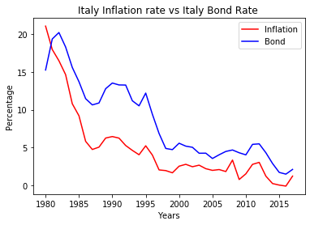

```python
# Python Code Here:
# Import the data sets
%matplotlib inline
import numpy as np
import pandas as pd
import matplotlib.pyplot as plt

italy_url = "https://raw.githubusercontent.com/dylanjm/econ_381_development/master/data/ch08_italy_inflation.csv"
italy = pd.read_csv(italy_url,header=0, names=['Date', 'Italy'])

ibond_url = "https://raw.githubusercontent.com/dylanjm/econ_381_development/master/data/ch08_italy_bond.csv"
ibond = pd.read_csv(ibond_url,header=0, names=['Date', 'iBond'])

#Convert the date variable to a datetime object
italy['Date'] = pd.to_datetime(italy['Date'])
italy['Year'] = italy['Date'].dt.year
ItalyInflation = np.array(italy['Italy'])

ibond['Date'] = pd.to_datetime(ibond['Date'])
ibond['Year'] = ibond['Date'].dt.year
ibondInflation = np.array(ibond['iBond'])


plt.title('Italy Inflation rate vs Italy Bond Rate ')
plt.xlabel('Years')
plt.plot(italy['Year'], ItalyInflation, label = "Inflation", c= "red")
plt.plot(ibond['Year'], ibondInflation, label ="Bond", c = "blue")
plt.ylabel('Percentage')
plt.legend()
plt.show()
```

**(b)**: Why do these two series tend to move together over time?

Bonds are issued by the goverment at a set market value rate, that incooperates inflation. As inflation changes, the bonds rate set price is changed to more accuratly match current market conditions. In this example with italy, as the inflation rate fell the italian goverment could offer the new bonds at a lower rate, and because purchasing power was growing, consumers would buy these bonds.

**(c)**: What economic concept corresponds to the difference between these two series?